# class notes 4.7

```r
library(tidyverse)
library(broom)
curved <- read_csv("curved.csv")
```

Let’s look at the `airquality` data set. First of all, are wind and temp independent?

```r
glimpse(airquality)
```

```
Rows: 153
Columns: 6
$ Ozone   <int> 41, 36, 12, 18, NA, 28, 23, 19, 8, NA, 7, 16, 11, 14, 18, 14, …
$ Solar.R <int> 190, 118, 149, 313, NA, NA, 299, 99, 19, 194, NA, 256, 290, 27…
$ Wind    <dbl> 7.4, 8.0, 12.6, 11.5, 14.3, 14.9, 8.6, 13.8, 20.1, 8.6, 6.9, 9…
$ Temp    <int> 67, 72, 74, 62, 56, 66, 65, 59, 61, 69, 74, 69, 66, 68, 58, 64…
$ Month   <int> 5, 5, 5, 5, 5, 5, 5, 5, 5, 5, 5, 5, 5, 5, 5, 5, 5, 5, 5, 5, 5,…
$ Day     <int> 1, 2, 3, 4, 5, 6, 7, 8, 9, 10, 11, 12, 13, 14, 15, 16, 17, 18,…
```

Null: wind and temp are independent. The slope of the regression line is zero in the population from which the sample is taken.

Alternative: they’re not independent. The slope in the population is nonzero.

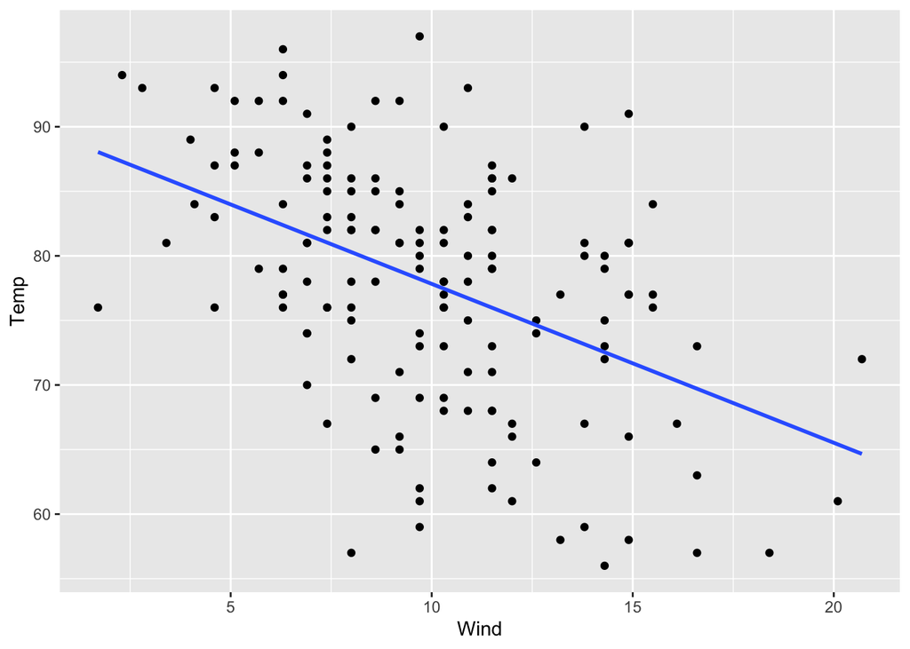

```r
ggplot(airquality,
       aes(x = Wind,
           y = Temp)) +
  geom_point() +
  geom_smooth(method = "lm",
              se = FALSE)
```

Now let’s run the test.

```r
model <- lm(Temp ~ Wind,
            data = airquality)
summary(model)
```

```
Call:
lm(formula = Temp ~ Wind, data = airquality)

Residuals:
    Min      1Q  Median      3Q     Max
-23.291  -5.723   1.709   6.016  19.199

Coefficients:
            Estimate Std. Error t value Pr(>|t|)
(Intercept)  90.1349     2.0522  43.921  < 2e-16 ***
Wind         -1.2305     0.1944  -6.331 2.64e-09 ***
---
Signif. codes:  0 '***' 0.001 '**' 0.01 '*' 0.05 '.' 0.1 ' ' 1

Residual standard error: 8.442 on 151 degrees of freedom
Multiple R-squared:  0.2098,    Adjusted R-squared:  0.2045
F-statistic: 40.08 on 1 and 151 DF,  p-value: 2.642e-09
```

The p-value (2.64 x 10^-9) indicates strong evidence against the null. We conclude that temp and wind are not independent. Knowing wind helps us guess temp.

## Regression from the practical perspective

Let’s leave inference aside for a bit. Once we have a model, we can compute predicted (or fitted) values and also residuals.

- fitted (predicted) values are obtained by plugging in to the regression equation.
- residuals are the difference between observed and expected values.

For observation 113, which has wind=15.5 and temp=77, the fitted value is 71.06315. (note my use of inline code here).

The residual of this point is (obs - exp) = 5.93685. That day was almost 6 degrees warmer than the model suggested.

We can extract all fitted values and all residuals at once:

```r
fitted.values(model)[1:10] # first 10
```

```
       1        2        3        4        5        6        7        8
81.02932 80.29104 74.63083 75.98436 72.53902 71.80073 79.55275 73.15426
       9       10
65.40224 79.55275
```

```r
residuals(model)[1:10]
```

```
          1           2           3           4           5           6
-14.0293228  -8.2910355  -0.6308326 -13.9843594 -16.5390184  -5.8007311
          7           8           9          10
-14.5527481 -14.1542579  -4.4022408 -10.5527481
```

The `broom::augment` does all this in a tidy manner.

```r
airq_aug <- augment(model)
glimpse(airq_aug)
```

```
Rows: 153
Columns: 8
$ Temp       <int> 67, 72, 74, 62, 56, 66, 65, 59, 61, 69, 74, 69, 66, 68, 58,…
$ Wind       <dbl> 7.4, 8.0, 12.6, 11.5, 14.3, 14.9, 8.6, 13.8, 20.1, 8.6, 6.9…
$ .fitted    <dbl> 81.02932, 80.29104, 74.63083, 75.98436, 72.53902, 71.80073,…
$ .resid     <dbl> -14.0293228, -8.2910355, -0.6308326, -13.9843594, -16.53901…
$ .hat       <dbl> 0.010003058, 0.008567096, 0.010237257, 0.007797113, 0.01653…
$ .sigma     <dbl> 8.391536, 8.442810, 8.469982, 8.392216, 8.359966, 8.456625,…
$ .cooksd    <dbl> 1.409331e-02, 4.203383e-03, 2.917589e-05, 1.086657e-02, 3.2…
$ .std.resid <dbl> -1.67021358, -0.98634611, -0.07511052, -1.66300885, -1.9755…
```

## Class Notes 4/9: Model Diagnostics

Assumptions:

- there is a linear relationship between the variables.
- the observations are independent of each other.
- residuals should have a normal distribution
- variance of said normal distribution should be the same for every x value

after making a regression model its pretty crucial to check these things, to make sure test is homoskedastic, among other things.

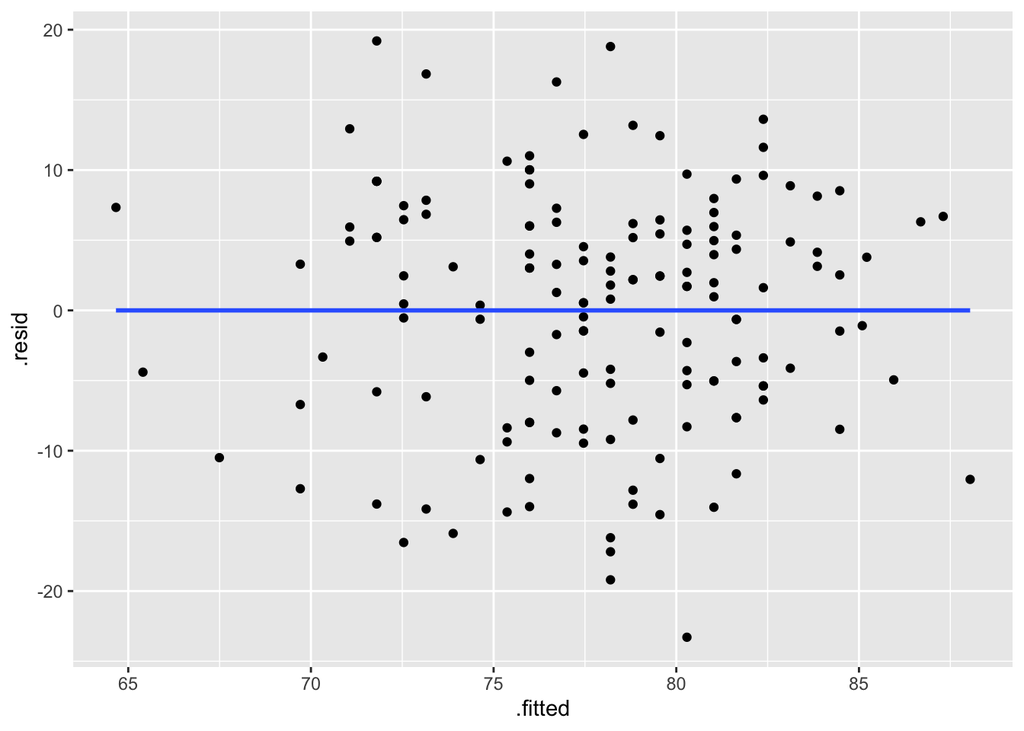

```r
ggplot(airq_aug, aes(x = .fitted, y = .resid)) +
  geom_point() +
  geom_smooth(method = "lm",
              se = FALSE)
```

assumptions 1, 3 and, 4 fulfilled - this should be a random cloud - no major patterns.

Lets look at `curved` now.

```r
glimpse(curved)
```

```
Rows: 200
Columns: 2
$ x <dbl> 2.6550866, 3.7212390, 5.7285336, 9.0820779, 2.0168193, 8.9838968, 9.…
$ y <dbl> 12.012418, 13.510693, 40.103471, 81.219909, 9.304237, 66.572104, 83.…
```

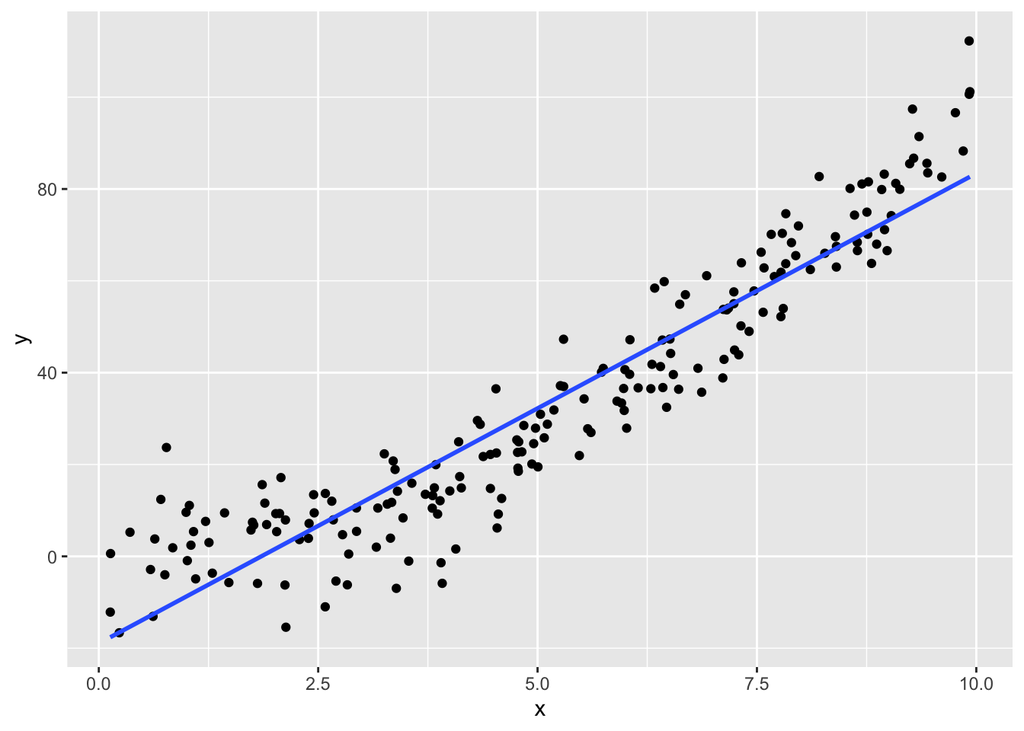

```r
ggplot(curved, aes(x = x,
                   y = y)) +
  geom_point() +
  geom_smooth(method = "lm",
             se = FALSE)
```

not a great model, but plot really doesnt look terrible. lets check out a residual plot:

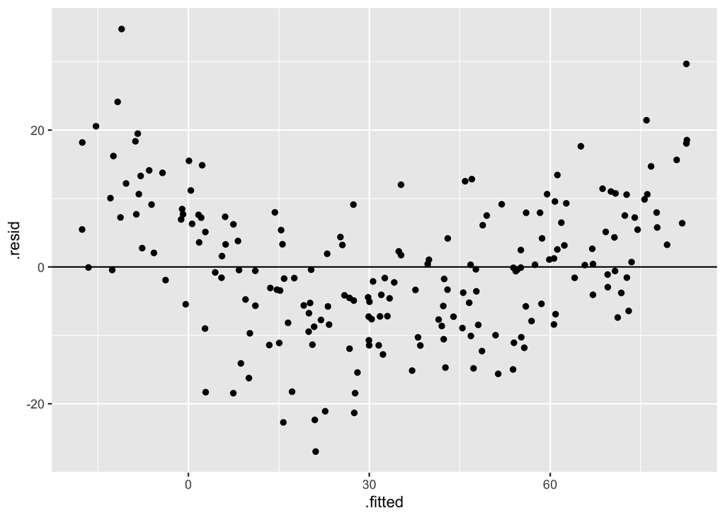

```r
model1 <- lm(y ~ x,
           data = curved)

curved_aug <- augment(model1)


ggplot(curved_aug,
       aes(x = .fitted,
           y = .resid)) +
  geom_point() +
  geom_hline(yintercept = 0)
```

## Predictions and what not: